# Risk Factor Analysis

## Outcome Variable

**Outcome Variable:** swasted

## Predictor Variables

**Intervention Variable:** vagbrth

**Adjustment Set:**

- arm
- sex
- W_mage
- meducyrs
- feducyrs
- hhwealth_quart
- hfoodsec
- W_mhtcm
- W_nrooms
- W_nchldlt5
- brthmon
- W_parity
- impfloor
- impsan
- safeh20
- delta_W_mage
- delta_meducyrs
- delta_feducyrs
- delta_hhwealth_quart
- delta_hfoodsec
- delta_W_mhtcm
- delta_W_nrooms
- delta_W_nchldlt5
- delta_brthmon
- delta_W_parity
- delta_impfloor
- delta_impsan
- delta_safeh20

## Stratifying Variables

The analysis was stratified on these variable(s):

- agecat
- studyid
- country

## Data Summary

| agecat | studyid | country | vagbrth | swasted | n_cell | n |
| --- | --- | --- | --- | --- | --- | --- |
| Birth | ki1000108-CMC-V-BCS-2002 | INDIA | 0 | 0 | 10 | 88 |
| Birth | ki1000108-CMC-V-BCS-2002 | INDIA | 0 | 1 | 0 | 88 |
| Birth | ki1000108-CMC-V-BCS-2002 | INDIA | 1 | 0 | 73 | 88 |
| Birth | ki1000108-CMC-V-BCS-2002 | INDIA | 1 | 1 | 5 | 88 |
| Birth | ki1000108-IRC | INDIA | 0 | 0 | 52 | 343 |
| Birth | ki1000108-IRC | INDIA | 0 | 1 | 14 | 343 |
| Birth | ki1000108-IRC | INDIA | 1 | 0 | 237 | 343 |
| Birth | ki1000108-IRC | INDIA | 1 | 1 | 40 | 343 |
| Birth | ki1017093c-NIH-Crypto | BANGLADESH | 0 | 0 | 1 | 17 |
| Birth | ki1017093c-NIH-Crypto | BANGLADESH | 0 | 1 | 0 | 17 |
| Birth | ki1017093c-NIH-Crypto | BANGLADESH | 1 | 0 | 15 | 17 |
| Birth | ki1017093c-NIH-Crypto | BANGLADESH | 1 | 1 | 1 | 17 |
| Birth | ki1119695-PROBIT | BELARUS | 0 | 0 | 1501 | 13824 |
| Birth | ki1119695-PROBIT | BELARUS | 0 | 1 | 92 | 13824 |
| Birth | ki1119695-PROBIT | BELARUS | 1 | 0 | 11412 | 13824 |
| Birth | ki1119695-PROBIT | BELARUS | 1 | 1 | 819 | 13824 |
| Birth | ki1126311-ZVITAMBO | ZIMBABWE | 0 | 0 | 1016 | 12813 |
| Birth | ki1126311-ZVITAMBO | ZIMBABWE | 0 | 1 | 83 | 12813 |
| Birth | ki1126311-ZVITAMBO | ZIMBABWE | 1 | 0 | 11011 | 12813 |
| Birth | ki1126311-ZVITAMBO | ZIMBABWE | 1 | 1 | 703 | 12813 |
| Birth | kiGH5241-JiVitA-3 | BANGLADESH | 0 | 0 | 4 | 31378 |
| Birth | kiGH5241-JiVitA-3 | BANGLADESH | 0 | 1 | 0 | 31378 |
| Birth | kiGH5241-JiVitA-3 | BANGLADESH | 1 | 0 | 30868 | 31378 |
| Birth | kiGH5241-JiVitA-3 | BANGLADESH | 1 | 1 | 506 | 31378 |
| Birth | kiGH5241-JiVitA-4 | BANGLADESH | 0 | 0 | 2 | 1366 |
| Birth | kiGH5241-JiVitA-4 | BANGLADESH | 0 | 1 | 0 | 1366 |
| Birth | kiGH5241-JiVitA-4 | BANGLADESH | 1 | 0 | 1354 | 1366 |
| Birth | kiGH5241-JiVitA-4 | BANGLADESH | 1 | 1 | 10 | 1366 |
| 6 months | ki1000108-CMC-V-BCS-2002 | INDIA | 0 | 0 | 25 | 368 |
| 6 months | ki1000108-CMC-V-BCS-2002 | INDIA | 0 | 1 | 0 | 368 |

[output cut: 70 more lines]

The following strata were considered:

- agecat: 24 months, studyid: ki1000108-CMC-V-BCS-2002, country: INDIA
- agecat: 24 months, studyid: ki1000108-IRC, country: INDIA
- agecat: 24 months, studyid: ki1017093b-PROVIDE, country: BANGLADESH
- agecat: 24 months, studyid: ki1017093c-NIH-Crypto, country: BANGLADESH
- agecat: 24 months, studyid: ki1066203-TanzaniaChild2, country: TANZANIA, UNITED REPUBLIC OF
- agecat: 24 months, studyid: ki1119695-PROBIT, country: BELARUS
- agecat: 24 months, studyid: ki1126311-ZVITAMBO, country: ZIMBABWE
- agecat: 24 months, studyid: kiGH5241-JiVitA-3, country: BANGLADESH
- agecat: 24 months, studyid: kiGH5241-JiVitA-4, country: BANGLADESH
- agecat: 6 months, studyid: ki1000108-CMC-V-BCS-2002, country: INDIA
- agecat: 6 months, studyid: ki1000108-IRC, country: INDIA
- agecat: 6 months, studyid: ki1017093b-PROVIDE, country: BANGLADESH
- agecat: 6 months, studyid: ki1017093c-NIH-Crypto, country: BANGLADESH
- agecat: 6 months, studyid: ki1066203-TanzaniaChild2, country: TANZANIA, UNITED REPUBLIC OF
- agecat: 6 months, studyid: ki1119695-PROBIT, country: BELARUS
- agecat: 6 months, studyid: ki1126311-ZVITAMBO, country: ZIMBABWE
- agecat: 6 months, studyid: kiGH5241-JiVitA-3, country: BANGLADESH
- agecat: 6 months, studyid: kiGH5241-JiVitA-4, country: BANGLADESH
- agecat: Birth, studyid: ki1000108-CMC-V-BCS-2002, country: INDIA
- agecat: Birth, studyid: ki1000108-IRC, country: INDIA
- agecat: Birth, studyid: ki1017093c-NIH-Crypto, country: BANGLADESH
- agecat: Birth, studyid: ki1119695-PROBIT, country: BELARUS
- agecat: Birth, studyid: ki1126311-ZVITAMBO, country: ZIMBABWE
- agecat: Birth, studyid: kiGH5241-JiVitA-3, country: BANGLADESH
- agecat: Birth, studyid: kiGH5241-JiVitA-4, country: BANGLADESH

### Dropped Strata

Some strata were dropped due to rare outcomes:

- agecat: Birth, studyid: ki1000108-CMC-V-BCS-2002, country: INDIA
- agecat: Birth, studyid: ki1017093c-NIH-Crypto, country: BANGLADESH
- agecat: Birth, studyid: kiGH5241-JiVitA-3, country: BANGLADESH
- agecat: Birth, studyid: kiGH5241-JiVitA-4, country: BANGLADESH
- agecat: 6 months, studyid: ki1000108-CMC-V-BCS-2002, country: INDIA
- agecat: 6 months, studyid: ki1000108-IRC, country: INDIA
- agecat: 6 months, studyid: ki1017093b-PROVIDE, country: BANGLADESH
- agecat: 6 months, studyid: ki1017093c-NIH-Crypto, country: BANGLADESH
- agecat: 6 months, studyid: ki1066203-TanzaniaChild2, country: TANZANIA, UNITED REPUBLIC OF
- agecat: 6 months, studyid: ki1119695-PROBIT, country: BELARUS
- agecat: 24 months, studyid: ki1000108-CMC-V-BCS-2002, country: INDIA
- agecat: 24 months, studyid: ki1000108-IRC, country: INDIA
- agecat: 24 months, studyid: ki1017093b-PROVIDE, country: BANGLADESH
- agecat: 24 months, studyid: ki1017093c-NIH-Crypto, country: BANGLADESH
- agecat: 24 months, studyid: ki1066203-TanzaniaChild2, country: TANZANIA, UNITED REPUBLIC OF
- agecat: 24 months, studyid: ki1119695-PROBIT, country: BELARUS
- agecat: 24 months, studyid: ki1126311-ZVITAMBO, country: ZIMBABWE

## Methods Detail

We’re interested in the causal parameters $E[Y_a]$ for all values of $a \in \mathcal{A}$. These parameters represent the mean outcome if, possibly contrary to fact, we intervened to set all units to have $A=a$. Under the randomization and positivity assumptions, these are identified by the statistical parameters $\psi_a=E_W[E_{Y|A,W}(Y|A=a,W)]$. In addition, we’re interested in the mean of $Y$, $E[Y]$ under no intervention (the observed mean). We will estimate these parameters by using SuperLearner to fit the relevant likelihood factors – $E_{Y|A,W}(Y|A=a,W)$ and $p(A=a|W)$, and then updating our likelihood fit using a joint TMLE.

For unadjusted analyses ($W=\{\}$), initial likelihoods were estimated using Lrnr_glm to estimate the simple $E(Y|A)$ and Lrnr_mean to estimate $p(A)$. For adjusted analyses, a small library containing Lrnr_glmnet, Lrnr_xgboost, and Lrnr_mean was used.

Having estimated these parameters, we will then use the delta method to estimate relative risks and attributable risks relative to a prespecified baseline level of $A$.

# Results Detail

## Results Plots

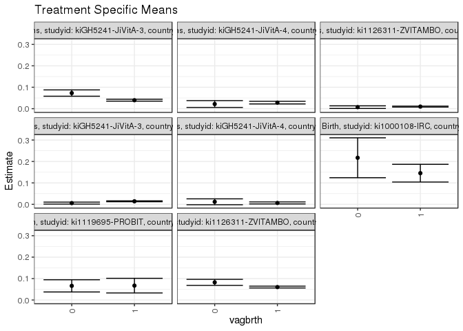

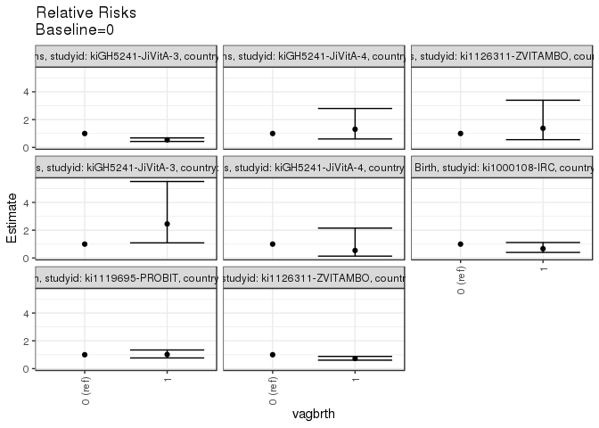

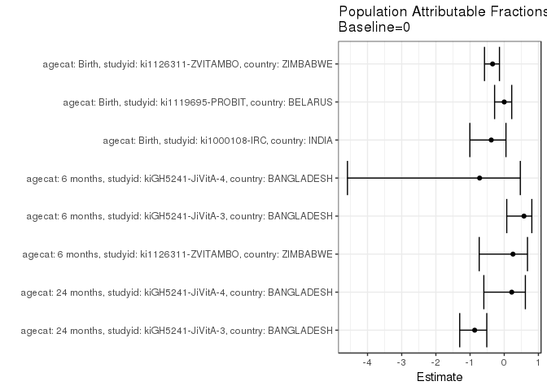

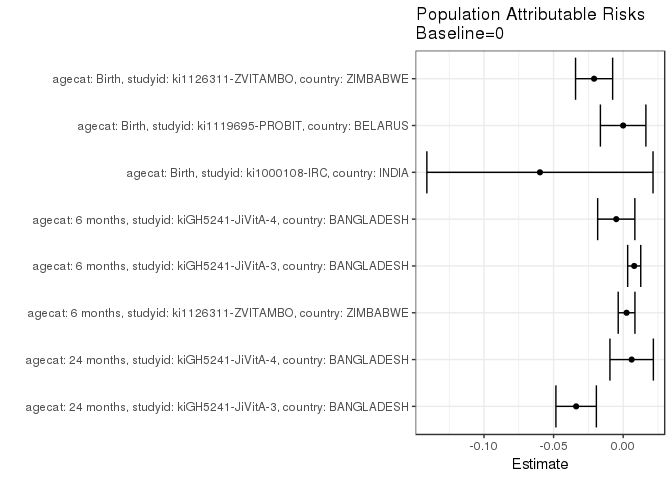

## Results Table

### Parameter: TSM

| agecat | studyid | country | intervention_level | baseline_level | estimate | ci_lower | ci_upper |
| --- | --- | --- | --- | --- | --- | --- | --- |
| Birth | ki1000108-IRC | INDIA | 0 | NA | 0.2172359 | 0.1241712 | 0.3103007 |
| Birth | ki1000108-IRC | INDIA | 1 | NA | 0.1454471 | 0.1041577 | 0.1867365 |
| Birth | ki1119695-PROBIT | BELARUS | 0 | NA | 0.0659241 | 0.0374137 | 0.0944346 |
| Birth | ki1119695-PROBIT | BELARUS | 1 | NA | 0.0670022 | 0.0328833 | 0.1011211 |
| Birth | ki1126311-ZVITAMBO | ZIMBABWE | 0 | NA | 0.0822414 | 0.0682198 | 0.0962630 |
| Birth | ki1126311-ZVITAMBO | ZIMBABWE | 1 | NA | 0.0602297 | 0.0559352 | 0.0645241 |
| 6 months | ki1126311-ZVITAMBO | ZIMBABWE | 0 | NA | 0.0070822 | 0.0008961 | 0.0132682 |
| 6 months | ki1126311-ZVITAMBO | ZIMBABWE | 1 | NA | 0.0097450 | 0.0075203 | 0.0119697 |
| 6 months | kiGH5241-JiVitA-3 | BANGLADESH | 0 | NA | 0.0057889 | 0.0011530 | 0.0104248 |
| 6 months | kiGH5241-JiVitA-3 | BANGLADESH | 1 | NA | 0.0141926 | 0.0120245 | 0.0163608 |
| 6 months | kiGH5241-JiVitA-4 | BANGLADESH | 0 | NA | 0.0118871 | -0.0018575 | 0.0256316 |
| 6 months | kiGH5241-JiVitA-4 | BANGLADESH | 1 | NA | 0.0064612 | 0.0017114 | 0.0112109 |
| 24 months | kiGH5241-JiVitA-3 | BANGLADESH | 0 | NA | 0.0728692 | 0.0581082 | 0.0876302 |
| 24 months | kiGH5241-JiVitA-3 | BANGLADESH | 1 | NA | 0.0394707 | 0.0350000 | 0.0439415 |
| 24 months | kiGH5241-JiVitA-4 | BANGLADESH | 0 | NA | 0.0216406 | 0.0056720 | 0.0376093 |
| 24 months | kiGH5241-JiVitA-4 | BANGLADESH | 1 | NA | 0.0282469 | 0.0220718 | 0.0344219 |

### Parameter: E(Y)

| agecat | studyid | country | intervention_level | baseline_level | estimate | ci_lower | ci_upper |
| --- | --- | --- | --- | --- | --- | --- | --- |
| Birth | ki1000108-IRC | INDIA | NA | NA | 0.1574344 | 0.1188345 | 0.1960344 |
| Birth | ki1119695-PROBIT | BELARUS | NA | NA | 0.0658999 | 0.0328405 | 0.0989593 |
| Birth | ki1126311-ZVITAMBO | ZIMBABWE | NA | NA | 0.0613439 | 0.0571889 | 0.0654990 |
| 6 months | ki1126311-ZVITAMBO | ZIMBABWE | NA | NA | 0.0095157 | 0.0074139 | 0.0116175 |
| 6 months | kiGH5241-JiVitA-3 | BANGLADESH | NA | NA | 0.0137109 | 0.0116412 | 0.0157807 |
| 6 months | kiGH5241-JiVitA-4 | BANGLADESH | NA | NA | 0.0069119 | 0.0024186 | 0.0114051 |
| 24 months | kiGH5241-JiVitA-3 | BANGLADESH | NA | NA | 0.0390712 | 0.0347380 | 0.0434044 |
| 24 months | kiGH5241-JiVitA-4 | BANGLADESH | NA | NA | 0.0277292 | 0.0218670 | 0.0335914 |

### Parameter: RR

| agecat | studyid | country | intervention_level | baseline_level | estimate | ci_lower | ci_upper |
| --- | --- | --- | --- | --- | --- | --- | --- |
| Birth | ki1000108-IRC | INDIA | 0 | 0 | 1.0000000 | 1.0000000 | 1.0000000 |
| Birth | ki1000108-IRC | INDIA | 1 | 0 | 0.6695351 | 0.4012299 | 1.1172578 |
| Birth | ki1119695-PROBIT | BELARUS | 0 | 0 | 1.0000000 | 1.0000000 | 1.0000000 |
| Birth | ki1119695-PROBIT | BELARUS | 1 | 0 | 1.0163534 | 0.7703702 | 1.3408803 |
| Birth | ki1126311-ZVITAMBO | ZIMBABWE | 0 | 0 | 1.0000000 | 1.0000000 | 1.0000000 |
| Birth | ki1126311-ZVITAMBO | ZIMBABWE | 1 | 0 | 0.7323522 | 0.6089617 | 0.8807445 |
| 6 months | ki1126311-ZVITAMBO | ZIMBABWE | 0 | 0 | 1.0000000 | 1.0000000 | 1.0000000 |
| 6 months | ki1126311-ZVITAMBO | ZIMBABWE | 1 | 0 | 1.3759978 | 0.5578710 | 3.3939209 |
| 6 months | kiGH5241-JiVitA-3 | BANGLADESH | 0 | 0 | 1.0000000 | 1.0000000 | 1.0000000 |
| 6 months | kiGH5241-JiVitA-3 | BANGLADESH | 1 | 0 | 2.4516856 | 1.0918536 | 5.5050990 |
| 6 months | kiGH5241-JiVitA-4 | BANGLADESH | 0 | 0 | 1.0000000 | 1.0000000 | 1.0000000 |
| 6 months | kiGH5241-JiVitA-4 | BANGLADESH | 1 | 0 | 0.5435456 | 0.1374955 | 2.1487376 |
| 24 months | kiGH5241-JiVitA-3 | BANGLADESH | 0 | 0 | 1.0000000 | 1.0000000 | 1.0000000 |
| 24 months | kiGH5241-JiVitA-3 | BANGLADESH | 1 | 0 | 0.5416651 | 0.4291382 | 0.6836984 |
| 24 months | kiGH5241-JiVitA-4 | BANGLADESH | 0 | 0 | 1.0000000 | 1.0000000 | 1.0000000 |
| 24 months | kiGH5241-JiVitA-4 | BANGLADESH | 1 | 0 | 1.3052688 | 0.6079127 | 2.8025844 |

### Parameter: PAR

| agecat | studyid | country | intervention_level | baseline_level | estimate | ci_lower | ci_upper |
| --- | --- | --- | --- | --- | --- | --- | --- |
| Birth | ki1000108-IRC | INDIA | 0 | NA | -0.0598015 | -0.1410512 | 0.0214481 |
| Birth | ki1119695-PROBIT | BELARUS | 0 | NA | -0.0000243 | -0.0163640 | 0.0163155 |
| Birth | ki1126311-ZVITAMBO | ZIMBABWE | 0 | NA | -0.0208974 | -0.0342195 | -0.0075754 |
| 6 months | ki1126311-ZVITAMBO | ZIMBABWE | 0 | NA | 0.0024335 | -0.0035742 | 0.0084412 |
| 6 months | kiGH5241-JiVitA-3 | BANGLADESH | 0 | NA | 0.0079220 | 0.0032252 | 0.0126188 |
| 6 months | kiGH5241-JiVitA-4 | BANGLADESH | 0 | NA | -0.0049752 | -0.0183393 | 0.0083889 |
| 24 months | kiGH5241-JiVitA-3 | BANGLADESH | 0 | NA | -0.0337980 | -0.0483346 | -0.0192614 |
| 24 months | kiGH5241-JiVitA-4 | BANGLADESH | 0 | NA | 0.0060886 | -0.0095125 | 0.0216896 |

### Parameter: PAF

| agecat | studyid | country | intervention_level | baseline_level | estimate | ci_lower | ci_upper |
| --- | --- | --- | --- | --- | --- | --- | --- |
| Birth | ki1000108-IRC | INDIA | 0 | NA | -0.3798505 | -1.0056169 | 0.0506725 |
| Birth | ki1119695-PROBIT | BELARUS | 0 | NA | -0.0003681 | -0.2818685 | 0.2193143 |
| Birth | ki1126311-ZVITAMBO | ZIMBABWE | 0 | NA | -0.3406600 | -0.5773921 | -0.1394563 |
| 6 months | ki1126311-ZVITAMBO | ZIMBABWE | 0 | NA | 0.2557383 | -0.7325140 | 0.6802765 |
| 6 months | kiGH5241-JiVitA-3 | BANGLADESH | 0 | NA | 0.5777876 | 0.0737080 | 0.8075517 |
| 6 months | kiGH5241-JiVitA-4 | BANGLADESH | 0 | NA | -0.7198047 | -4.5871655 | 0.4706210 |
| 24 months | kiGH5241-JiVitA-3 | BANGLADESH | 0 | NA | -0.8650375 | -1.3026600 | -0.5105855 |
| 24 months | kiGH5241-JiVitA-4 | BANGLADESH | 0 | NA | 0.2195722 | -0.5968568 | 0.6185835 |